# Bayesian Networks - Tutorial

- Show All Code
- Hide All Code
- View Source

Network psychometrics Summer School - Como 2025

Author

Giovanni Briganti

Published

August 4, 2025

## Executive Summary

**Overview**

This tutorial explores the relationships between depression symptoms using **Bayesian networks**. We employ multiple algorithms (PC, Hill Climbing, and Restricted Maximization) to identify directed symptom connections and evaluate network stability through bootstrap procedures. Interpret carefully based on the notions explained during the lecture.

**Methods:**

- PC Algorithm for constraint-based learning
- Hill Climbing for score-based optimization
- Restricted Maximization (RSMAX2) hybrid approach
- Bootstrap stability analysis (n=1000)

## 1 Bayesian Networks: key concepts

### 1.1 Core BN Components

**Structure:** Directed Acyclic Graph (DAG)

- **Nodes**: Symptoms/variables
- **Directed edges**: Conditional dependencies
- **No cycles**: Prevents circular causation

**Probability:** Joint distribution factorization $P(X_1, X_2, ..., X_n) = \prod_{i=1}^{n} P(X_i | Pa(X_i))$

### 1.2 Markov Blanket

For any node X, the **Markov blanket MB(X)** includes:

- **Parents Pa(X)**: Direct causes → X
- **Children Ch(X)**: Direct effects X →
- **Spouses Sp(X)**: Co-parents of X’s children

**Key property**: X is independent of everything else given MB(X)

### 1.3 d-Separation

**A path is blocked by conditioning set Z if:** 1. **Non-collider W** on path: W ∈ Z

2. **Collider W** on path: Neither W nor descendants ∈ Z

**Colliders are special**: X → Z ← Y

- X and Y independent unconditionally
- X and Y become dependent when conditioning on Z

### 1.4 Structure Learning Algorithms

| Type | Method | Key Features |
| --- | --- | --- |
| **Constraint-based** | Conditional independence tests | PC algorithm, d-separation |
| **Score-based** | Optimize network score | Hill Climbing |
| **Hybrid** | Combine both approaches | RSMAX2 |

### 1.5 Conditional Independence Tests

**Data type determines test:**

- **Discrete**: Asymptotic χ² test
- **Continuous**: Hotelling’s modified t-test
- **Ordinal**: Jonckheere-Terpstra test

### 1.6 Causal Inference Conditions

**For rigorous causal claims:**

1. **Causal sufficiency**: All causes measured
2. **No latent confounders**: No hidden common causes
3. **Causal faithfulness**: Connected variables are dependent
4. **No selection bias**: Representative data

### 1.7 Bootstrap Stability Assessment

**Standard thresholds:**

- **Edge strength > 85%**: Appears in >85% of bootstrap samples
- **Direction > 50%**: Consistent direction across samples

### 1.8 What BNs Can Do for You

**Clinical applications:**

1. **Identify predictive models**: Local predictors for each symptom
2. **Detect v-structures**: Understand collider relationships
3. **Generate hypotheses**: Fast, data-driven research questions
4. **Address complexity**: Handle multivariate symptom interactions

**Research workflow:** - Retrospective data → Research questions

- Design studies → Collect data
- Analyze relationships → Interpret results

### 1.9 Key Limitations

- **Multiple testing**: Many independence tests inflate Type I error
- **Statistical power**: Decreases with larger conditioning sets
- **Equivalence classes**: Recovery of CPDAG, not full DAG
- **Sample size**: Large N needed for stability

### 1.10 Practical Interpretation

**Note**

When assumptions are met, BNs can perform **causal inference**

When assumptions are not met, BNs still useful for **hypothesis generation**

## 2 Setup and Data Preparation

### 2.1 Package Installation and Loading

**Load required libraries**

```r
# Load required libraries for statistical analysis and network modeling
library(tidyverse)
library(qgraph)
library(bootnet)
library(bnlearn)
library(knitr)
library(DT)
library(kableExtra)

# Set visualization theme
theme_set(theme_minimal() +
          theme(plot.title = element_text(hjust = 0.5, size = 14, face = "bold"),
                plot.subtitle = element_text(hjust = 0.5, size = 12)))
```

### 2.2 Data Import and Symptom Definitions

**Data Requirements**

1. Download the `data.csv` file or upload directly from GitHub
2. Ensure the CSV file uses semicolon (`;`) as delimiter

**Import and prepare depression symptom data**

```r
# Import depression symptomatology data
depression_symptom_data <- read_delim("https://raw.githubusercontent.com/giovannibriganti/BNcomo2025/refs/heads/main/data.csv",
                                      delim = ";",
                                      escape_double = FALSE,
                                      trim_ws = TRUE)

# Define symptom labels for analysis and visualization
symptom_short_names <- c("DepMood",
                         "Sleep",
                         "Weight",
                         "Fatigue",
                         "Irritable",
                         "SuicideId",
                         "Anhedonia")

symptom_clinical_descriptions <- c("Depressed Mood",
                                   "Sleep Disturbance",
                                   "Weight/Appetite Changes",
                                   "Fatigue/Loss of Energy",
                                   "Irritability",
                                   "Suicidal Ideation",
                                   "Anhedonia")

# Create a mapping table for reference
symptom_mapping <- data.frame(
  Short_Name = symptom_short_names,
  Clinical_Description = symptom_clinical_descriptions,
  stringsAsFactors = FALSE
)
```

**Display symptom mapping**

```r
kable(symptom_mapping,
      col.names = c("Short Name", "Clinical Description"),
      align = c("l", "l")) |>
  kableExtra::kable_styling(bootstrap_options = c("striped", "hover", "condensed"),
                           full_width = FALSE)
```

Depression Symptom Labels and Clinical Descriptions

| Short Name | Clinical Description |
| --- | --- |
| DepMood | Depressed Mood |
| Sleep | Sleep Disturbance |
| Weight | Weight/Appetite Changes |
| Fatigue | Fatigue/Loss of Energy |
| Irritable | Irritability |
| SuicideId | Suicidal Ideation |
| Anhedonia | Anhedonia |

## 3 PC Algorithm Analysis

**PC Algorithm Overview**

The **PC (Peter-Clark) algorithm** learns network structure using conditional independence tests to identify direct symptom relationships. It’s a constraint-based approach that systematically tests for conditional independence between variables.

**Run PC algorithm analysis**

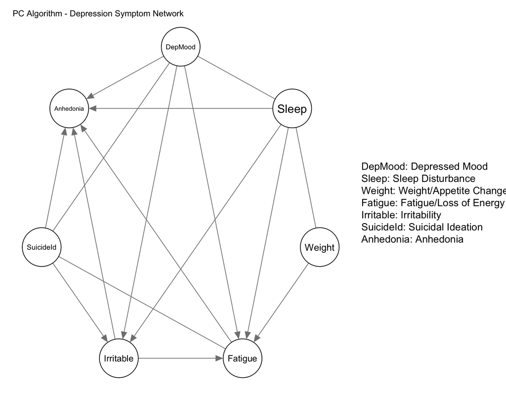

PC Algorithm - Depression Symptom Network

```r
# The PC algorithm learns the structure of a Bayesian network
# using conditional independence tests
depression_network_pc <- pc.stable(depression_symptom_data)

# Generate PC algorithm network visualization
qgraph(depression_network_pc,
       labels = symptom_short_names,
       nodeNames = symptom_clinical_descriptions,
       legend.cex = 0.6,
       vsize = 8,
       layout = "circle",
       title = "PC Algorithm - Depression Symptom Network")
```

## 4 Bootstrap Stability Analysis for PC Algorithm

**Warning**

**Bootstrap stability analysis for PC algorithm**

```r
# Bootstrap analysis evaluates the stability of symptom network connections
# Strength: Proportion of bootstrap samples where connection appears (>0.85 recommended)
# Direction: Probability of edge direction (>0.5 for reliable direction)
# NOT RUN
# pc_bootstrap_results <- boot.strength(depression_symptom_data, R = 1000, algorithm = "pc.stable")
```

**Visualize PC bootstrap results**

```r
# Visualize bootstrap results
# qgraph(pc_bootstrap_results, title = "PC Algorithm Bootstrap Results", labels = symptom_short_names)
```

### 4.1 PC Algorithm Stable Connections

**Filter and display stable PC connections**

```r
# Filter for stable connections (strength > 0.85 AND direction > 0.5)
# pc_stable_connections <- pc_bootstrap_results[pc_bootstrap_results$strength > 0.85 & pc_bootstrap_results$direction > 0.5, ]
```

## 5 Hill Climbing Algorithm Analysis

**Note**

**Run Hill Climbing bootstrap analysis**

```r
# Hill Climbing bootstrap analysis
hill_climbing_bootstrap <- boot.strength(depression_symptom_data,
                                         R = 1000,
                                         algorithm = "hc",
                                         debug = FALSE)
```

### 5.1 Hill Climbing Stable Connections

**Filter and visualize stable Hill Climbing connections**

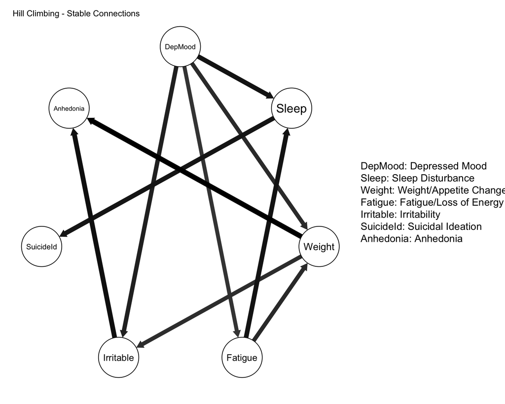

Hill Climbing - Stable Connections

```r
# Filter for stable connections (strength > 0.85 AND direction > 0.5)
hc_stable_connections <- hill_climbing_bootstrap[(hill_climbing_bootstrap$strength > 0.85) &
                                                   (hill_climbing_bootstrap$direction > 0.5), ]

# Visualize Hill Climbing stable connections
qgraph(hc_stable_connections,
       title = "Hill Climbing - Stable Connections",
       labels = symptom_short_names,
       nodeNames = symptom_clinical_descriptions,
       layout="circle")
```

## 6 Equivalence Classes Analysis

**CPDAG Explained**

**Completed Partially Directed Acyclic Graphs (CPDAGs)** represent equivalence classes of DAGs that have the same conditional independence relationships among symptoms. Undirected edges indicate that the direction cannot be determined from the data alone.

**Generate CPDAG from PC algorithm results**

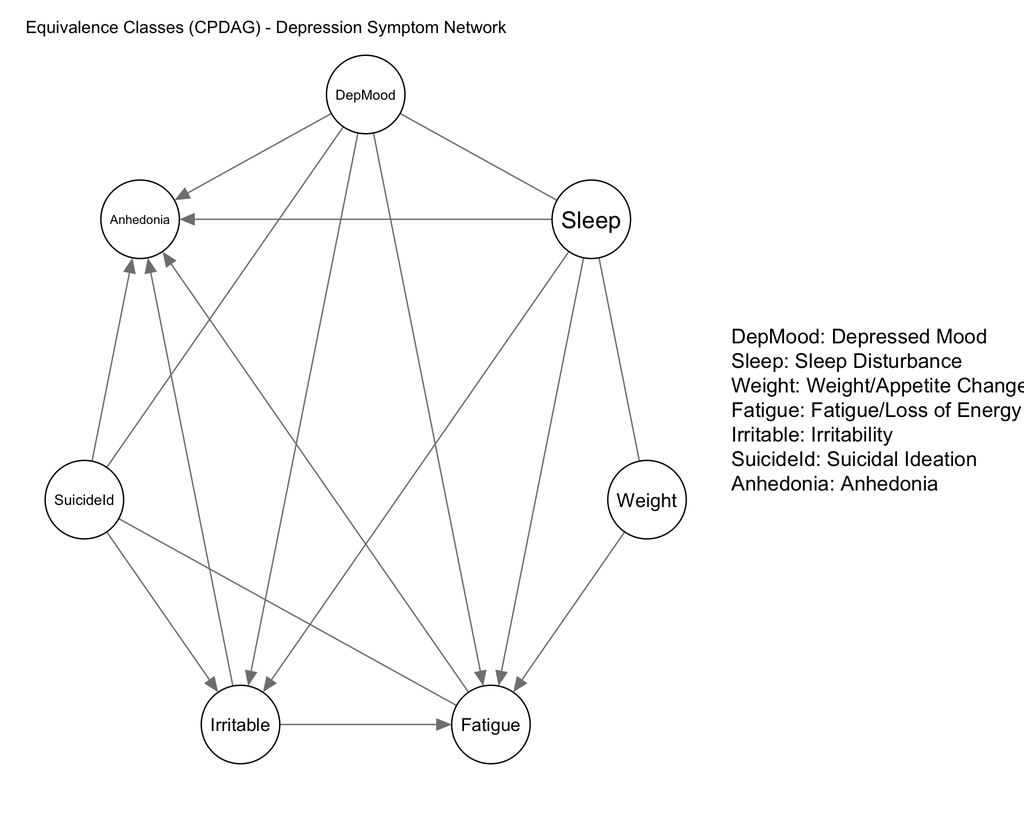

Equivalence Classes (CPDAG) - Depression Symptom Network

```r
# Convert PC algorithm result to CPDAG
pc_equivalence_class <- cpdag(depression_network_pc)

# Generate CPDAG visualization
qgraph(pc_equivalence_class,
       labels = symptom_short_names,
       nodeNames = symptom_clinical_descriptions,
       legend.cex = 0.6,
       vsize = 8,
       layout = "circle",
       title = "Equivalence Classes (CPDAG) - Depression Symptom Network")
```

## 7 Restricted Maximization Hybrid Algorithm

**RSMAX2 Algorithm**

The **Restricted Maximization (RSMAX2)** algorithm combines constraint-based and score-based approaches for network structure learning. It first uses constraint-based methods to identify the skeleton, then applies score-based optimization for edge direction.

**Run RSMAX2 algorithm**

```r
# The RSMAX2 algorithm combines constraint-based and score-based approaches
depression_network_rsmax <- rsmax2(depression_symptom_data)

# Bootstrap analysis for RSMAX2
rsmax_bootstrap_results <- boot.strength(depression_symptom_data,
                                         R = 1000,
                                         algorithm = "rsmax2",
                                         debug = FALSE)
```

### 7.1 RSMAX2 Stable Connections

**Filter and visualize stable RSMAX2 connections**

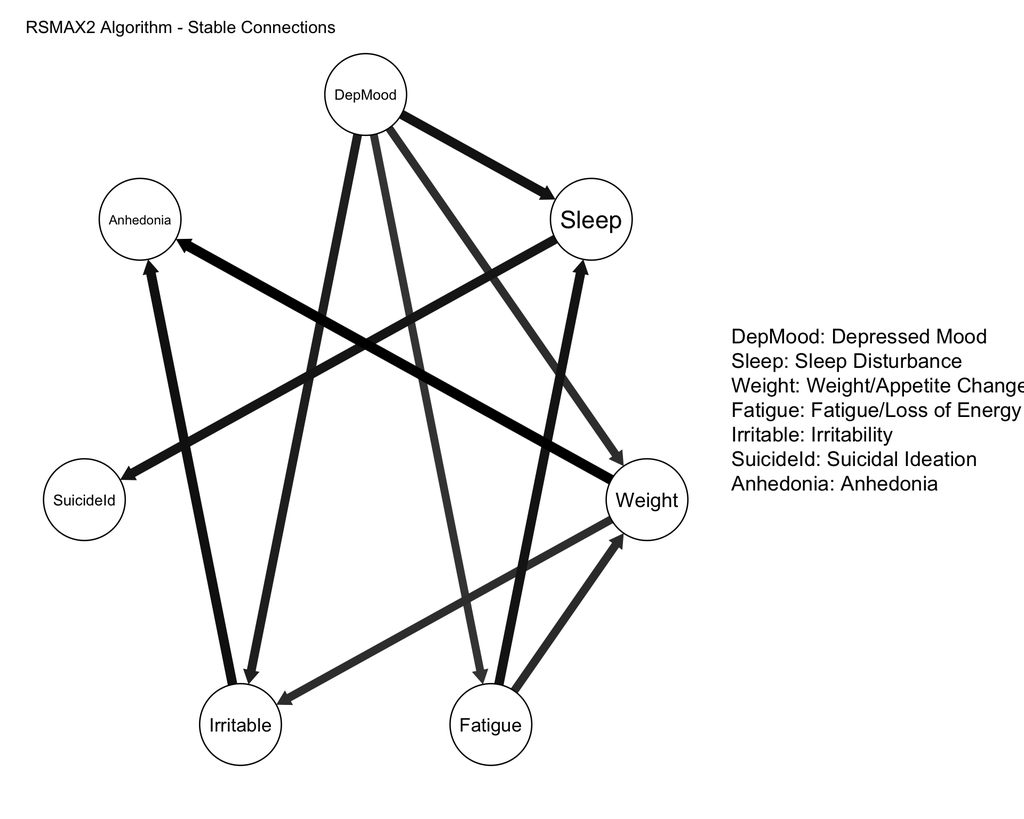

RSMAX2 Algorithm - Stable Connections

```r
# Filter for stable connections (strength > 0.85 AND direction > 0.5)
rsmax_stable_connections <- rsmax_bootstrap_results[rsmax_bootstrap_results$strength > 0.85 &
                                                      rsmax_bootstrap_results$direction > 0.5, ]

qgraph(rsmax_stable_connections,
       title = "RSMAX2 Algorithm - Stable Connections",
       labels = symptom_short_names,
       nodeNames = symptom_clinical_descriptions,
       layout="circle")
```

### 7.2 Comparison of Hill-Climbing and RSMAX2 algorithms

**Comparison of Hill-Climbing and RSMAX2 algorithms**

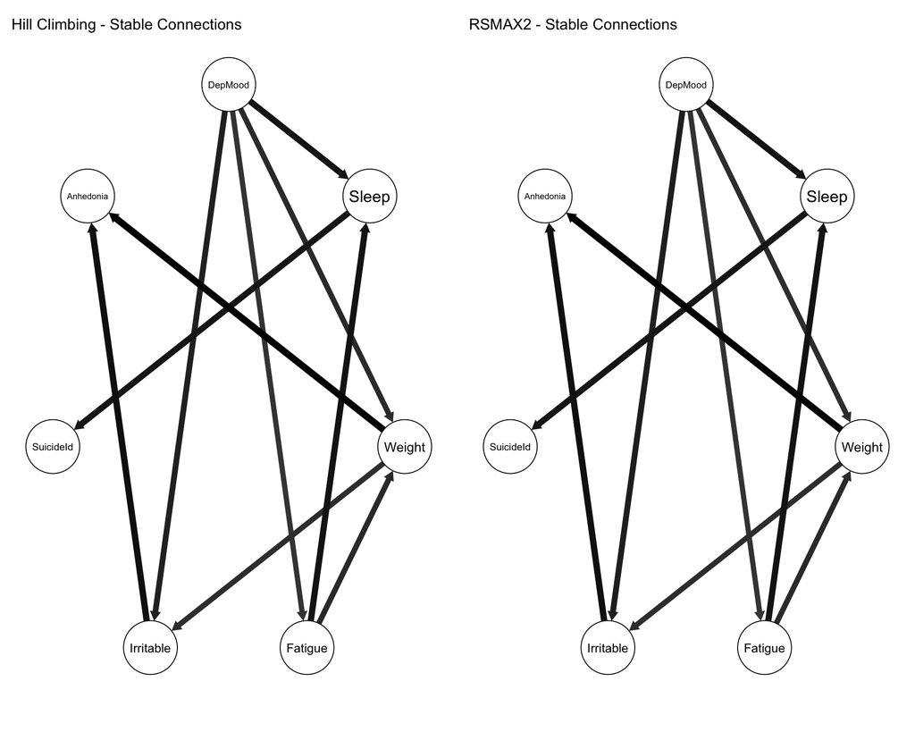

```r
# Side-by-side comparison of Hill Climbing and RSMAX2
par(mfrow = c(1, 2))

# Hill Climbing plot
qgraph(hc_stable_connections,
       title = "Hill Climbing - Stable Connections",
       labels = symptom_short_names,
       layout="circle")

# RSMAX2 plot
qgraph(rsmax_stable_connections,
       title = "RSMAX2 - Stable Connections",
       labels = symptom_short_names,
       layout="circle")
```

**Comparison of Hill-Climbing and RSMAX2 algorithms**

```r
# Reset plot layout
par(mfrow = c(1, 1))
```

## 8 Summary and Interpretation

**Key points**

**Stability Criteria:** Connections are considered stable when:

- **Strength > 0.85**: Connection appears in >85% of bootstrap samples
- **Direction > 0.5**: Edge direction is consistent in >50% of cases

**Algorithm Comparison:**

- **PC Algorithm**: Constraint-based, identifies conditional independence
- **Hill Climbing**: Score-based, optimizes network score greedily
- **RSMAX2**: Hybrid approach combining both methodologies